# Powerlifting Project: Descriptive Statistics

Andrés De Freitas Carmona

2025-01-03

# Contextualizing the Sport: Powerlifting’s Descriptive Analysis

The descriptive analysis for this project serves one main purpose: **contextualize** how *Powerlifting* works and how its variables behave, especially to the public outside of the sport.

As a strength and weightlifting competitive sport, *Powerlifting* accounts for numerous measurable variables with meaningful value. Collecting data not only helps for accountability, it also allows to turn the sport into a subject of study. In this case, Powerlifting will be reviewed from a Data Science perspective.

Glossary of variables:

- **IPF**: Stands for International Powerlifting Federation, currently one of the most important in the sport.
- **Equipment**: There are two types of equipment, Raw and Single-Ply, in the IPF. Essentially, the equipment determines the conditions in which athletes compete.
- **Division**: Age groups where athletes compete.
- **Weight class**: Weight categories based on athletes’ body weight.
- **TotalKg**: Total weight lifted by an athlete in a competition.
- **Federation**: Each federation has its own equipment rules, with different divisions and weight classes.
- **MeetName**: Name of the competition.
- **Goodlift points (GL)**: A measure of athletes’ performance based on their body weight and other coefficients.

IPF website for more info: www.powerlifting.sport

# 1. Libraries

```r
library(readr)
library(dplyr)
library(lubridate)
library(ggplot2)
library(tidyr)
```

# 2. Data loading

```r
openpowerliftingdata <- read_csv("C:/Users/andre/OneDrive/Escritorio/TFM/openpowerliftingdata3.csv")
```

# 3. Data division

1. Data is split in female and male data sets, allowing for better data management.
2. Data has been filtered for the International Powerlifting Federation (IPF), one of the most important federations in the sport.

```r
ipf_male_data <- openpowerliftingdata %>% filter(Federation == "IPF", Sex == "M")
ipf_female_data <- openpowerliftingdata %>% filter(Federation == "IPF", Sex == "F")
```

# 4. Data cleaning

### 4.1. Convert variables to factors.

```r
ipf_male_data <- ipf_male_data %>%
  mutate(
    WeightClassKg = as.factor(WeightClassKg),
    Division = as.factor(Division),
    Equipment = as.factor(Equipment)
  )

ipf_female_data <- ipf_female_data %>%
  mutate(
    WeightClassKg = as.factor(WeightClassKg),
    Division = as.factor(Division),
    Equipment = as.factor(Equipment)
  )
```

### 4.2. Classifying competitions by movements.

Not all competitions host all three movements in their events. There are either one or three movement competitions.

```r
# Male

ipf_male_data <- ipf_male_data %>%
  mutate(
    BooleanSquat = ifelse(
      is.na(Bench1Kg) & is.na(Bench2Kg) & is.na(Bench3Kg) & is.na(Bench4Kg) & is.na(Best3BenchKg) &
        is.na(Deadlift1Kg) & is.na(Deadlift2Kg) & is.na(Deadlift3Kg) & is.na(Deadlift4Kg) & is.na(Best3DeadliftKg) &
        (!is.na(Squat1Kg) | !is.na(Squat2Kg) | !is.na(Squat3Kg) | !is.na(Squat4Kg) | !is.na(Best3SquatKg)),
      1, 0
    ),
    BooleanBench = ifelse(
      is.na(Squat1Kg) & is.na(Squat2Kg) & is.na(Squat3Kg) & is.na(Squat4Kg) & is.na(Best3SquatKg) &
        is.na(Deadlift1Kg) & is.na(Deadlift2Kg) & is.na(Deadlift3Kg) & is.na(Deadlift4Kg) & is.na(Best3DeadliftKg) &
        (!is.na(Bench1Kg) | !is.na(Bench2Kg) | !is.na(Bench3Kg) | !is.na(Bench4Kg) | !is.na(Best3BenchKg)),
      1, 0
    ),
    BooleanDeadlift = ifelse(
      is.na(Squat1Kg) & is.na(Squat2Kg) & is.na(Squat3Kg) & is.na(Squat4Kg) & is.na(Best3SquatKg) &
        is.na(Bench1Kg) & is.na(Bench2Kg) & is.na(Bench3Kg) & is.na(Bench4Kg) & is.na(Best3BenchKg) &
        (!is.na(Deadlift1Kg) | !is.na(Deadlift2Kg) | !is.na(Deadlift3Kg) | !is.na(Deadlift4Kg) | !is.na(Best3DeadliftKg)),
      1, 0
    ),
    BooleanDisq = ifelse(
      (is.na(Squat1Kg) & is.na(Squat2Kg) & is.na(Squat3Kg) & is.na(Squat4Kg) & is.na(Best3SquatKg) &
         is.na(Bench1Kg) & is.na(Bench2Kg) & is.na(Bench3Kg) & is.na(Bench4Kg) & is.na(Best3BenchKg) &
         is.na(Deadlift1Kg) & is.na(Deadlift2Kg) & is.na(Deadlift3Kg) & is.na(Deadlift4Kg) & is.na(Best3DeadliftKg)) |
        Place == "DQ",
      1, 0
    )
  )

# Female

ipf_female_data <- ipf_female_data %>%
  mutate(
    BooleanSquat = ifelse(
      is.na(Bench1Kg) & is.na(Bench2Kg) & is.na(Bench3Kg) & is.na(Bench4Kg) & is.na(Best3BenchKg) &
        is.na(Deadlift1Kg) & is.na(Deadlift2Kg) & is.na(Deadlift3Kg) & is.na(Deadlift4Kg) & is.na(Best3DeadliftKg) &
        (!is.na(Squat1Kg) | !is.na(Squat2Kg) | !is.na(Squat3Kg) | !is.na(Squat4Kg) | !is.na(Best3SquatKg)),
      1, 0
    ),
    BooleanBench = ifelse(
      is.na(Squat1Kg) & is.na(Squat2Kg) & is.na(Squat3Kg) & is.na(Squat4Kg) & is.na(Best3SquatKg) &
        is.na(Deadlift1Kg) & is.na(Deadlift2Kg) & is.na(Deadlift3Kg) & is.na(Deadlift4Kg) & is.na(Best3DeadliftKg) &
        (!is.na(Bench1Kg) | !is.na(Bench2Kg) | !is.na(Bench3Kg) | !is.na(Bench4Kg) | !is.na(Best3BenchKg)),
      1, 0
    ),
    BooleanDeadlift = ifelse(
      is.na(Squat1Kg) & is.na(Squat2Kg) & is.na(Squat3Kg) & is.na(Squat4Kg) & is.na(Best3SquatKg) &
        is.na(Bench1Kg) & is.na(Bench2Kg) & is.na(Bench3Kg) & is.na(Bench4Kg) & is.na(Best3BenchKg) &
        (!is.na(Deadlift1Kg) | !is.na(Deadlift2Kg) | !is.na(Deadlift3Kg) | !is.na(Deadlift4Kg) | !is.na(Best3DeadliftKg)),
      1, 0
    ),
    BooleanDisq = ifelse(
      (is.na(Squat1Kg) & is.na(Squat2Kg) & is.na(Squat3Kg) & is.na(Squat4Kg) & is.na(Best3SquatKg) &
         is.na(Bench1Kg) & is.na(Bench2Kg) & is.na(Bench3Kg) & is.na(Bench4Kg) & is.na(Best3BenchKg) &
         is.na(Deadlift1Kg) & is.na(Deadlift2Kg) & is.na(Deadlift3Kg) & is.na(Deadlift4Kg) & is.na(Best3DeadliftKg)) |
        Place == "DQ",
      1, 0
    )
  )
```

### 4.3. Removing competitions with only one movement.

An important step in the data cleaning process of this project is the removal of competitions that do not execute the three movements. This criterion is a fundamental principle of the project and will be discussed later.

```r
# Male

ipf_male_data_clean <- ipf_male_data %>%
  filter(
    (BooleanSquat + BooleanBench + BooleanDeadlift != 1) &
      (BooleanDisq == 0)
  )

# Female

ipf_female_data_clean <- ipf_female_data %>%
  filter(
    (BooleanSquat + BooleanBench + BooleanDeadlift != 1) &
      (BooleanDisq == 0)
  )
```

### 4.4. Removing boolean variables created, since they no longer serve any purpose.

```r
ipf_male_data_clean <- ipf_male_data_clean %>%
  select(-BooleanSquat, -BooleanBench, -BooleanDeadlift, -BooleanDisq)

ipf_female_data_clean <- ipf_female_data_clean %>%
  select(-BooleanSquat, -BooleanBench, -BooleanDeadlift, -BooleanDisq)
```

### 4.5. Removing old divisions.

**Divisions** evolved through time. Nowadays, the IPF ceased the use of the following.

```r
excluded_divisions <- c("Light", "Middle", "Heavy", "Super", "SOI", "SuperHeavy")

ipf_male_data_clean <- ipf_male_data_clean %>%
  filter(!Division %in% excluded_divisions)

ipf_female_data_clean <- ipf_female_data_clean %>%
  filter(!Division %in% excluded_divisions)
```

### 4.6. Removing disqualified athletes.

```r
excluded_places <- c("DD", "DQ", "G")

ipf_male_data_clean <- ipf_male_data_clean %>%
  filter(!Place %in% excluded_places)

ipf_female_data_clean <- ipf_female_data_clean %>%
  filter(!Place %in% excluded_places)
```

# 5. Descriptive Statistics for the Powerlifting Project

### 5.1. Number of athletes by equipment and sex.

Men represent the majority of athletes in the sport. However, women do not fall behind in the **Raw** equipment section.

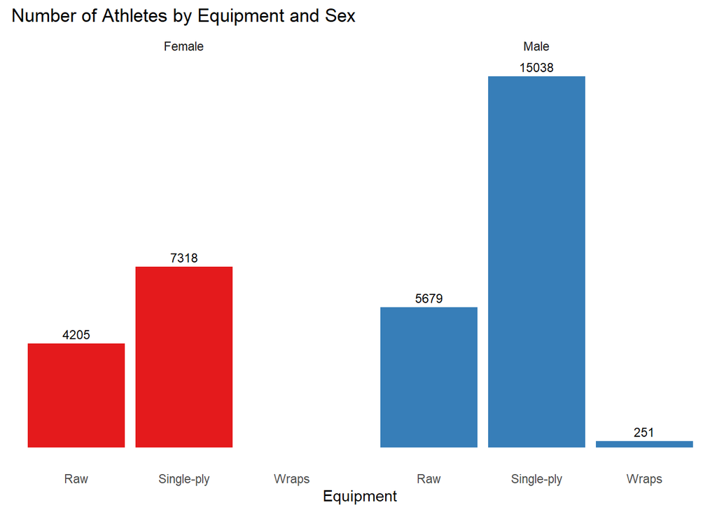

```r
combined_data_clean <- bind_rows(
  ipf_male_data_clean %>% mutate(Sex = "Male"),
  ipf_female_data_clean %>% mutate(Sex = "Female")
)

combined_equipment_plot <- combined_data_clean %>%
  group_by(Sex, Equipment) %>%
  summarise(Count = n()) %>%
  ggplot(aes(x = Equipment, y = Count, fill = Sex)) +
  geom_bar(stat = "identity", position = "dodge") +
  geom_text(aes(label = Count), position = position_dodge(width = 0.9), vjust = -0.5, size = 3) +
  scale_fill_brewer(palette = "Set1") +
  theme_minimal() +
  labs(title = "Number of Athletes by Equipment and Sex",
       x = "Equipment",
       y = NULL) +
  theme(
    panel.grid = element_blank(),
    legend.position = "none",
    axis.title.y = element_blank(),
    axis.text.y = element_blank(),
    axis.ticks.y = element_blank()
  ) +
  facet_wrap(~Sex)


print(combined_equipment_plot)
```

### 5.2. Divisions by equipment.

Divisions in both sides are similarly distributed in terms of number of athletes. The **Open** division is the most important, followed by the **Juniors**.

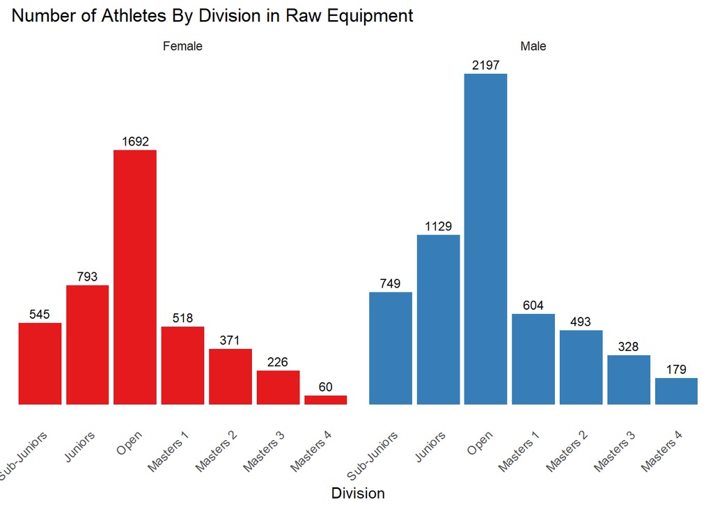

```r
division_order <- c("Sub-Juniors", "Juniors", "Open", "Masters 1", "Masters 2", "Masters 3", "Masters 4")

ipf_male_data_clean <- ipf_male_data_clean %>%
  mutate(Division = factor(Division, levels = division_order))

ipf_female_data_clean <- ipf_female_data_clean %>%
  mutate(Division = factor(Division, levels = division_order))


# Raw

raw_combined_plot <- combined_data_clean %>%
  filter(Equipment == "Raw", !is.na(Division)) %>%
  group_by(Sex, Division) %>%
  summarise(Count = n()) %>%
  mutate(Division = factor(Division, levels = division_order)) %>%
  ggplot(aes(x = Division, y = Count, fill = Sex)) +
  geom_bar(stat = "identity", position = "dodge") +
  geom_text(aes(label = Count), position = position_dodge(width = 0.9), vjust = -0.5, size = 3) +
  scale_fill_brewer(palette = "Set1") +
  theme_minimal() +
  labs(title = "Number of Athletes By Division in Raw Equipment",
       x = "Division",
       y = NULL) +
  theme(
    panel.grid = element_blank(),
    legend.position = "none",
    axis.title.y = element_blank(),
    axis.text.y = element_blank(),
    axis.ticks.y = element_blank(),
    axis.text.x = element_text(angle = 45, hjust = 1)
  ) +
  facet_wrap(~Sex)

print(raw_combined_plot)
```

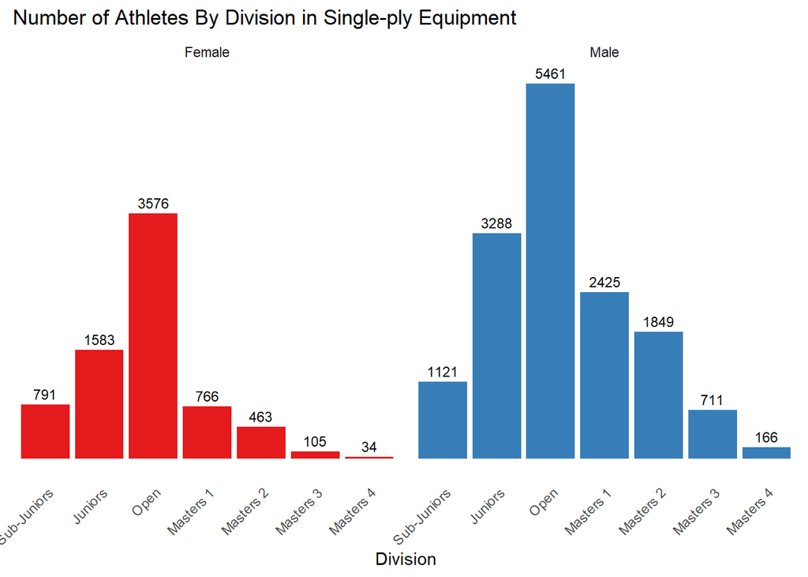

```r
# Single-ply

single_ply_combined_plot <- combined_data_clean %>%
  filter(Equipment == "Single-ply" & !is.na(Division)) %>%
  group_by(Sex, Division) %>%
  summarise(Count = n()) %>%
  mutate(Division = factor(Division, levels = division_order)) %>%
  ggplot(aes(x = Division, y = Count, fill = Sex)) +
  geom_bar(stat = "identity", position = "dodge") +
  geom_text(aes(label = Count), position = position_dodge(width = 0.9), vjust = -0.5, size = 3) +
  scale_fill_brewer(palette = "Set1") +
  theme_minimal() +
  labs(title = "Number of Athletes By Division in Single-ply Equipment",
       x = "Division",
       y = NULL) +
  theme(
    panel.grid = element_blank(),
    legend.position = "none",
    axis.title.y = element_blank(),
    axis.text.y = element_blank(),
    axis.ticks.y = element_blank(),
    axis.text.x = element_text(angle = 45, hjust = 1)
  ) +
  facet_wrap(~Sex)

print(single_ply_combined_plot)
```

### 5.3. Weight classes by division and equipment from 2011 and 2018.

Number of athletes by weight class in the top 3 divisions with **Raw** equipment.

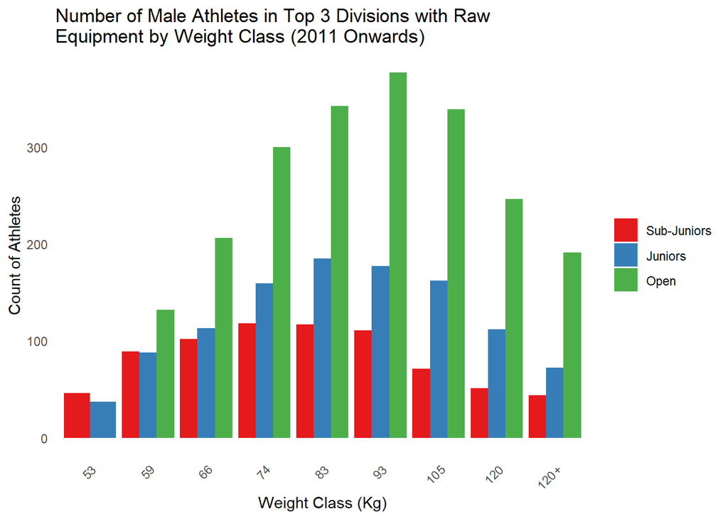

```r
# Ordering weight classes.

male_weight_order <- c("52", "53", "56", "59", "60", "66", "67.5", "74", "75", "82.5", "82.5+", "83", "90", "90+", "93", "100", "100+", "105", "105+", "110", "110+", "120", "120+", "125", "125+")

ipf_male_data_clean <- ipf_male_data_clean %>%
  mutate(WeightClassKg = factor(WeightClassKg, levels = male_weight_order))

female_weight_order <- c("43", "44", "47", "48", "52", "56", "57", "60", "63", "67.5", "67.5+", "69", "72", "72+", "75", "75+", "76", "76+", "82.5", "82.5+", "84", "84+", "90", "90+")

ipf_female_data_clean <- ipf_female_data_clean %>%
  mutate(WeightClassKg = factor(WeightClassKg, levels = female_weight_order))

# Filtering top 3 divisions.

get_top_divisions <- function(data, equipment) {
  data %>%
    filter(Equipment == equipment) %>%
    group_by(Division) %>%
    summarise(Count = n(), .groups = 'drop') %>%
    arrange(desc(Count)) %>%
    slice_head(n = 3) %>%
    pull(Division)
}

top_divisions_male_raw <- get_top_divisions(ipf_male_data_clean, "Raw")
top_divisions_male_single_ply <- get_top_divisions(ipf_male_data_clean, "Single-ply")
top_divisions_female_raw <- get_top_divisions(ipf_female_data_clean, "Raw")
top_divisions_female_single_ply <- get_top_divisions(ipf_female_data_clean, "Single-ply")

filter_top_divisions <- function(data, divisions) {
  data %>%
    filter(Division %in% divisions)
}

filtered_male_raw <- filter_top_divisions(ipf_male_data_clean, top_divisions_male_raw)
filtered_male_single_ply <- filter_top_divisions(ipf_male_data_clean, top_divisions_male_single_ply)
filtered_female_raw <- filter_top_divisions(ipf_female_data_clean, top_divisions_female_raw)
filtered_female_single_ply <- filter_top_divisions(ipf_female_data_clean, top_divisions_female_single_ply)

# 2011

weight_class_plot_2011 <- function(data, divisions, equipment, sex) {

  division_colors <- c(
    "Sub-Juniors" = "#E41A1C",
    "Juniors" = "#377EB8",
    "Open" = "#4DAF4A",
    "Masters 1" = "#984EA3"
  )

  data %>%
    filter(Division %in% divisions,
           Equipment == equipment,
           !is.na(WeightClassKg),
           Date >= as.Date("2011-01-01")) %>%
    group_by(Division, WeightClassKg) %>%
    summarise(Count = n(), .groups = 'drop') %>%
    ggplot(aes(x = WeightClassKg, y = Count, fill = Division)) +
    geom_bar(stat = "identity", position = "dodge") +
    scale_fill_manual(values = division_colors) +
    theme_minimal() +
    labs(title = paste("Number of", sex, "Athletes in Top 3 Divisions with", equipment, "\nEquipment by Weight Class (2011 Onwards)"),
         x = "Weight Class (Kg)",
         y = "Count of Athletes") +
    theme(
      panel.grid = element_blank(),
      axis.text.x = element_text(angle = 45, hjust = 1),
      legend.title = element_blank()
    )
}


plot_male_raw_2011 <- weight_class_plot_2011(filtered_male_raw, top_divisions_male_raw, "Raw", "Male")
print(plot_male_raw_2011)
```

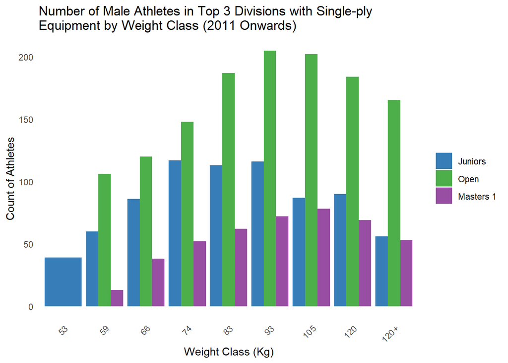

```r
plot_male_single_ply_2011 <- weight_class_plot_2011(filtered_male_single_ply, top_divisions_male_single_ply, "Single-ply", "Male")
print(plot_male_single_ply_2011)
```

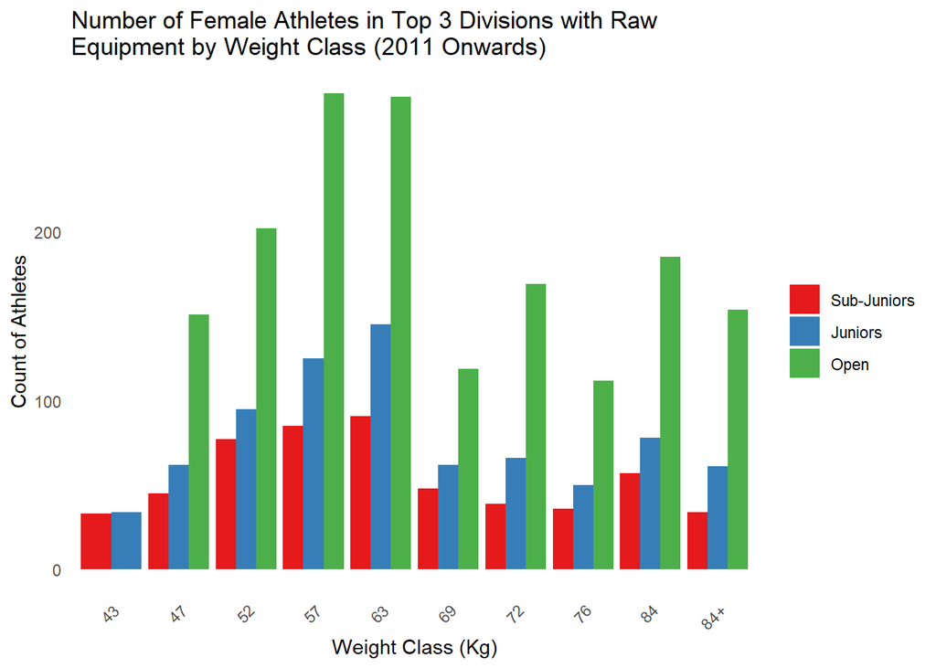

```r
plot_female_raw_2011 <- weight_class_plot_2011(filtered_female_raw, top_divisions_female_raw, "Raw", "Female")
print(plot_female_raw_2011)
```

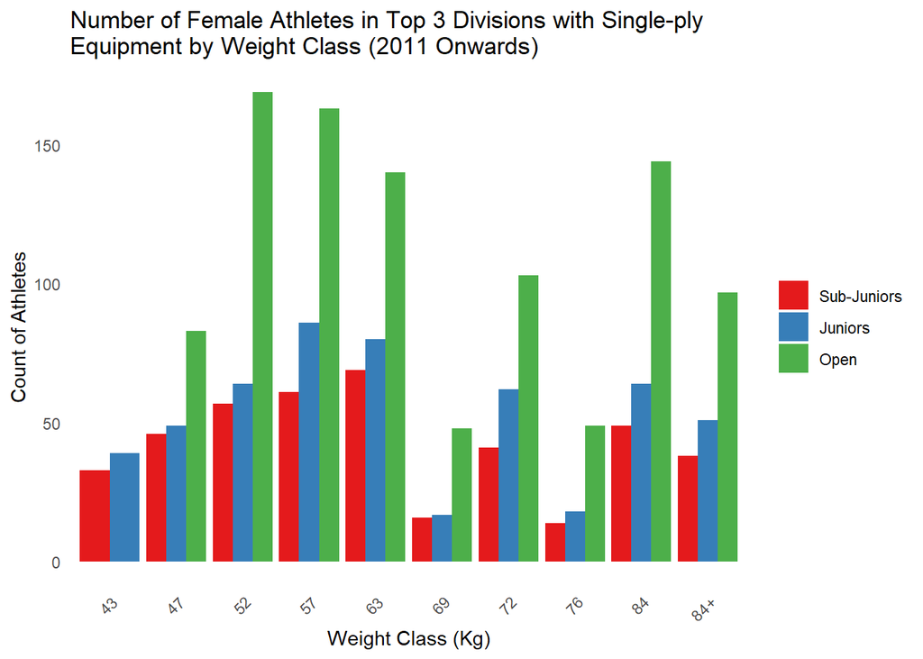

```r
plot_female_single_ply_2011 <- weight_class_plot_2011(filtered_female_single_ply, top_divisions_female_single_ply, "Single-ply", "Female")
print(plot_female_single_ply_2011)
```

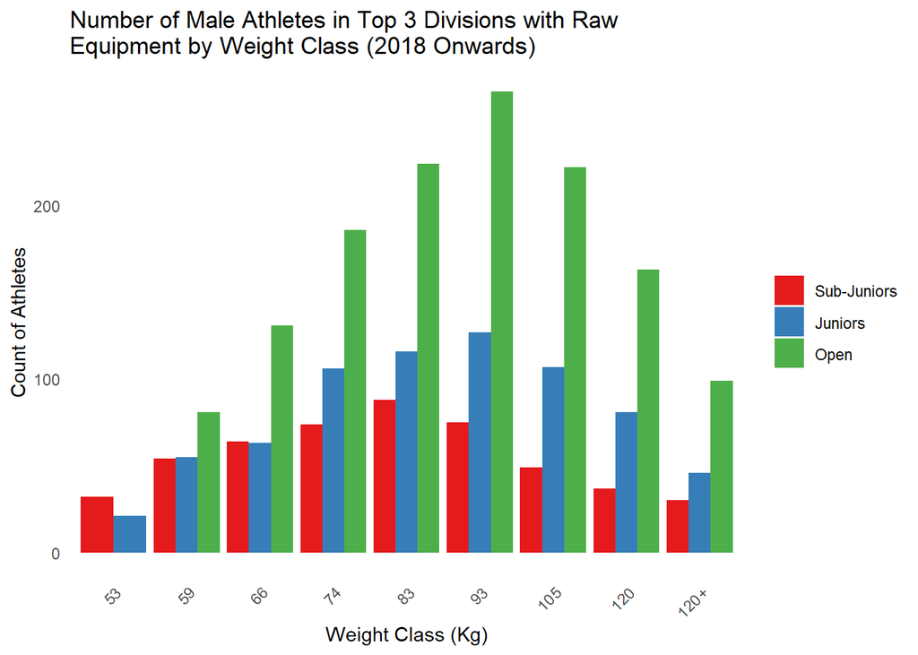

```r
# 2018

weight_class_plot_2018 <- function(data, divisions, equipment, sex) {

  division_colors <- c(
    "Sub-Juniors" = "#E41A1C",
    "Juniors" = "#377EB8",
    "Open" = "#4DAF4A",
    "Masters 1" = "#984EA3"
  )

  data %>%
    filter(Division %in% divisions,
           Equipment == equipment,
           !is.na(WeightClassKg),
           Date >= as.Date("2018-01-01")) %>%
    group_by(Division, WeightClassKg) %>%
    summarise(Count = n(), .groups = 'drop') %>%
    ggplot(aes(x = WeightClassKg, y = Count, fill = Division)) +
    geom_bar(stat = "identity", position = "dodge") +
    scale_fill_manual(values = division_colors) +
    theme_minimal() +
    labs(title = paste("Number of", sex, "Athletes in Top 3 Divisions with", equipment, "\nEquipment by Weight Class (2018 Onwards)"),
         x = "Weight Class (Kg)",
         y = "Count of Athletes") +
    theme(
      panel.grid = element_blank(),
      axis.text.x = element_text(angle = 45, hjust = 1),
      legend.title = element_blank()
    )
}


plot_male_raw_2018 <- weight_class_plot_2018(filtered_male_raw, top_divisions_male_raw, "Raw", "Male")
print(plot_male_raw_2018)
```

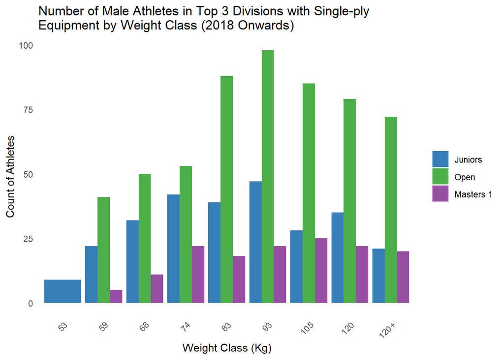

```r
plot_male_single_ply_2018 <- weight_class_plot_2018(filtered_male_single_ply, top_divisions_male_single_ply, "Single-ply", "Male")
print(plot_male_single_ply_2018)
```

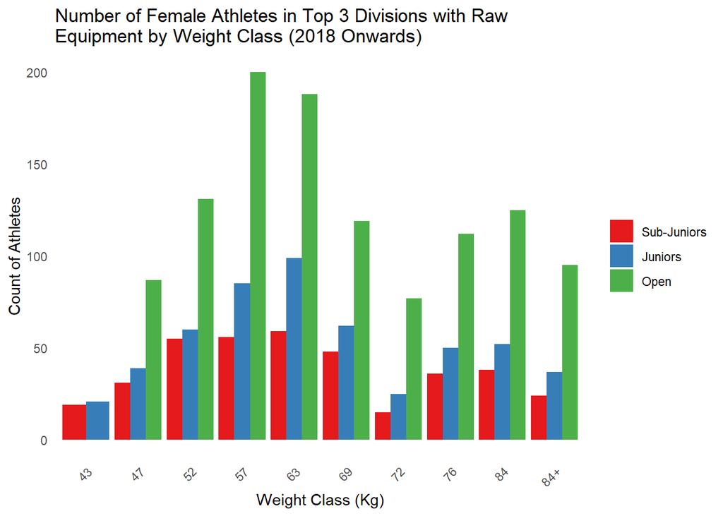

```r
plot_female_raw_2018 <- weight_class_plot_2018(filtered_female_raw, top_divisions_female_raw, "Raw", "Female")
print(plot_female_raw_2018)
```

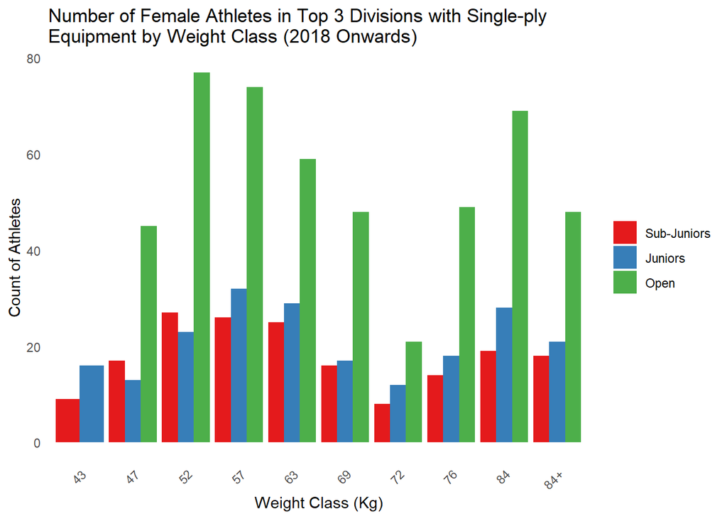

```r
plot_female_single_ply_2018 <- weight_class_plot_2018(filtered_female_single_ply, top_divisions_female_single_ply, "Single-ply", "Female")
print(plot_female_single_ply_2018)
```

### 5.4. Weight classes timeline.

**Weight classes** have changed during the sport´s history. Here is a visual representation of how they have evolved.

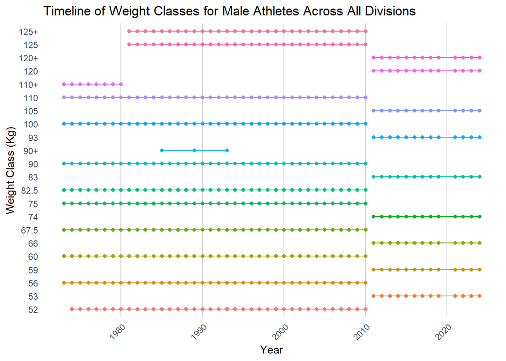

```r
filtered_male <- ipf_male_data_clean %>%
  filter(!is.na(WeightClassKg))

filtered_female <- ipf_female_data_clean %>%
  filter(!is.na(WeightClassKg))


create_timeline_plot <- function(data, sex) {
  data %>%
    group_by(Year = as.integer(format(Date, "%Y")), WeightClassKg) %>%
    summarise(Count = n(), .groups = 'drop') %>%
    ggplot(aes(x = Year, y = WeightClassKg, group = WeightClassKg, color = WeightClassKg)) +
    geom_line() +
    geom_point() +
    theme_minimal() +
    labs(title = paste("Timeline of Weight Classes for", sex, "Athletes Across All Divisions"),
         x = "Year",
         y = "Weight Class (Kg)") +
    theme(axis.text.x = element_text(angle = 45, hjust = 1),
          legend.position = "none",
          panel.grid = element_blank(),
          panel.grid.major.x = element_line(color = "gray80"))
}


plot_male_timeline <- create_timeline_plot(filtered_male, "Male")
plot_female_timeline <- create_timeline_plot(filtered_female, "Female")

print(plot_male_timeline)
```

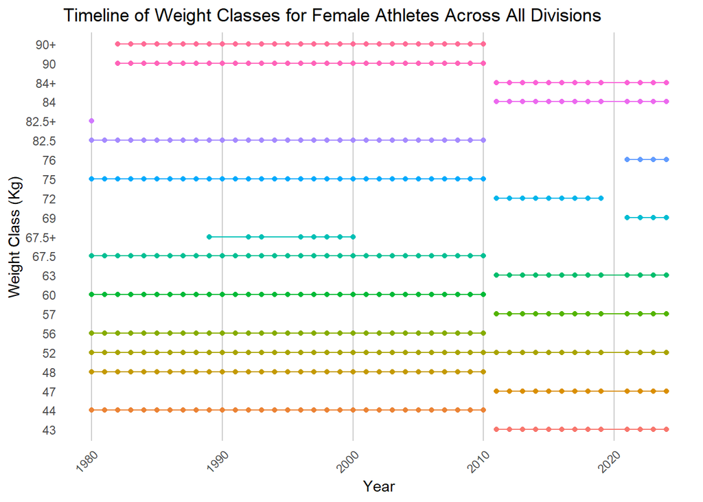

```r
print(plot_female_timeline)
```

### 5.5. Bodyweight density plot by sex (historical perspective).

Historically, women´s **body weight** has been more concentrated than men´s. Women´s **weight classes** have been criticized as unrealistic for the context of the sport.

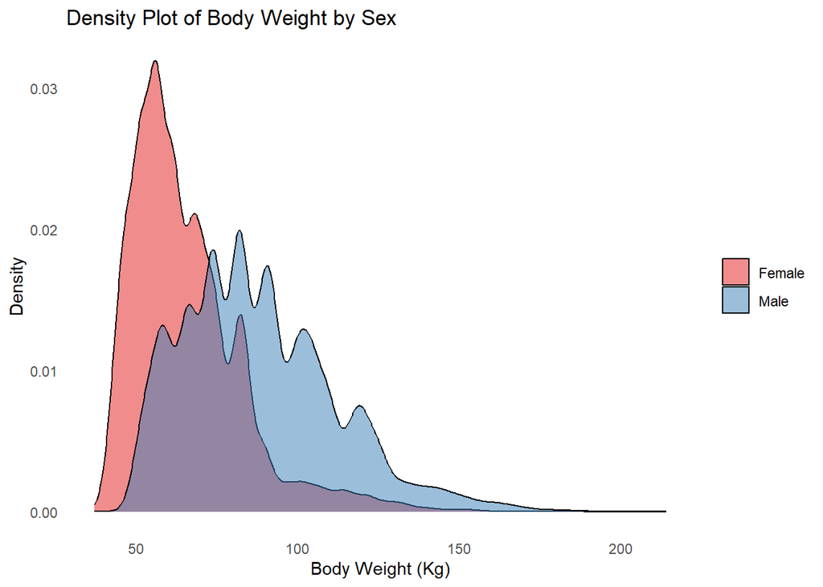

```r
combined_data <- bind_rows(
  ipf_male_data_clean %>%
    mutate(Sex = "Male"),
  ipf_female_data_clean %>%
    mutate(Sex = "Female")
)

density_bodyweight <- ggplot(combined_data, aes(x = BodyweightKg, fill = Sex)) +
  geom_density(alpha = 0.5) +
  theme_minimal() +
  labs(title = "Density Plot of Body Weight by Sex",
       x = "Body Weight (Kg)",
       y = "Density") +
  scale_fill_brewer(palette = "Set1") +
  theme(
    legend.title = element_blank(),
    panel.grid = element_blank()
  )

print(density_bodyweight)
```

### 5.6. Bodyweight density plot from 2011 and 2018.

As **weight classes** gain more athletes through time, spikes in the density plots can be visualized.

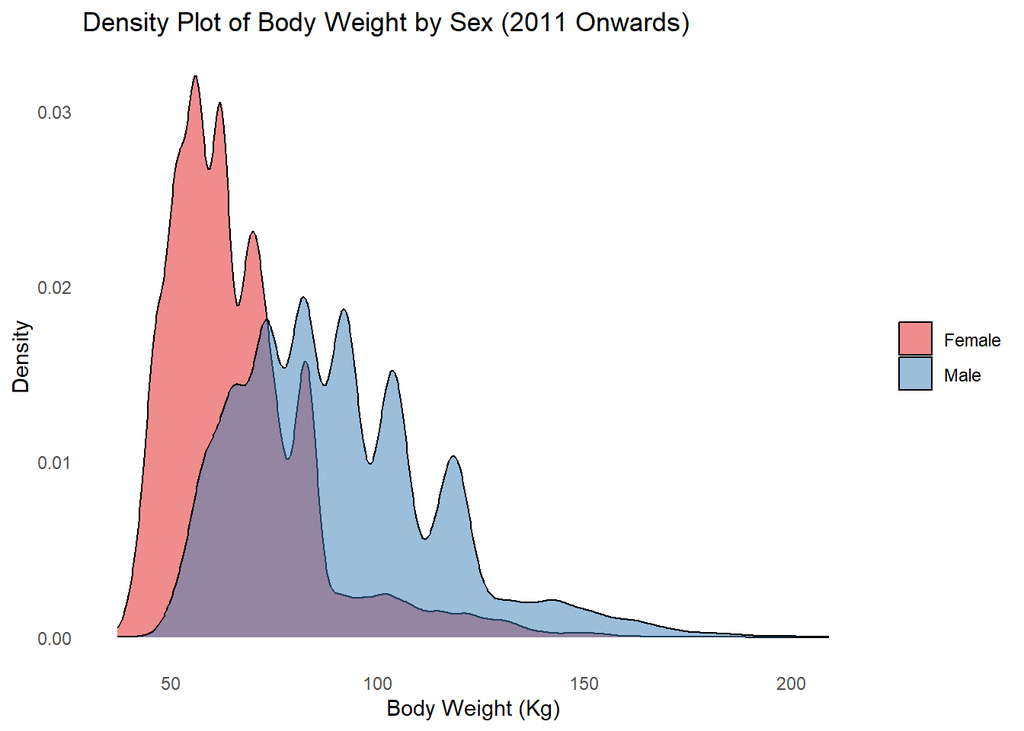

```r
# 2011

ipf_male_data_2011_onwards <- ipf_male_data_clean %>%
  filter(Date >= as.Date("2011-01-01"))

ipf_female_data_2011_onwards <- ipf_female_data_clean %>%
  filter(Date >= as.Date("2011-01-01"))

combined_data_2011_onwards <- bind_rows(
  ipf_male_data_2011_onwards %>%
    mutate(Sex = "Male"),
  ipf_female_data_2011_onwards %>%
    mutate(Sex = "Female")
)

density_bodyweight_2011_onwards <- ggplot(combined_data_2011_onwards, aes(x = BodyweightKg, fill = Sex)) +
  geom_density(alpha = 0.5) +
  theme_minimal() +
  labs(title = "Density Plot of Body Weight by Sex (2011 Onwards)",
       x = "Body Weight (Kg)",
       y = "Density") +
  scale_fill_brewer(palette = "Set1") +
  theme(
    legend.title = element_blank(),
    panel.grid = element_blank()
  )

print(density_bodyweight_2011_onwards)
```

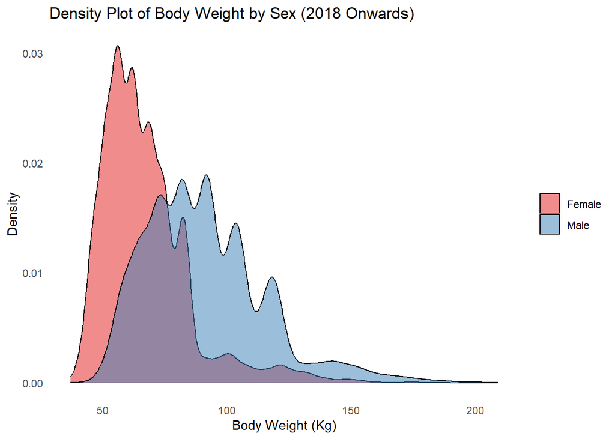

```r
# 2018

ipf_male_data_2018_onwards <- ipf_male_data_clean %>%
  filter(Date >= as.Date("2018-01-01"))

ipf_female_data_2018_onwards <- ipf_female_data_clean %>%
  filter(Date >= as.Date("2018-01-01"))

combined_data_2018_onwards <- bind_rows(
  ipf_male_data_2018_onwards %>%
    mutate(Sex = "Male"),
  ipf_female_data_2018_onwards %>%
    mutate(Sex = "Female")
)

density_bodyweight_2018_onwards <- ggplot(combined_data_2018_onwards, aes(x = BodyweightKg, fill = Sex)) +
  geom_density(alpha = 0.5) +
  theme_minimal() +
  labs(title = "Density Plot of Body Weight by Sex (2018 Onwards)",
       x = "Body Weight (Kg)",
       y = "Density") +
  scale_fill_brewer(palette = "Set1") +
  theme(
    legend.title = element_blank(),
    panel.grid = element_blank()
  )

print(density_bodyweight_2018_onwards)
```

### 5.7. Boxplot of totals per weight class on Open division, Raw equipment, from 2011 and 2018.

**Weight classes** and **TotalKg** lifted by athletes correlate positive. From a physics standpoint, a higher **body weight** allows to lift heavier.

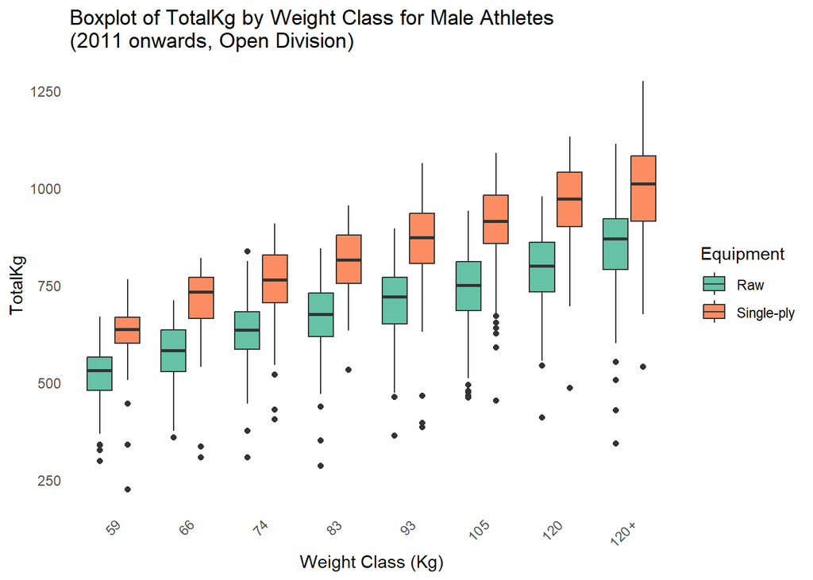

```r
# 2011

# Male

ipf_male_data_2011_onwards_open <- ipf_male_data_clean %>%
  filter(Date >= as.Date("2011-01-01") & Division == "Open") %>%
  filter(!is.na(WeightClassKg))

male_boxplot_2011_onwards_open <- ggplot(ipf_male_data_2011_onwards_open, aes(x = as.factor(WeightClassKg), y = TotalKg, fill = Equipment)) +
  geom_boxplot() +
  theme_minimal() +
  labs(title = "Boxplot of TotalKg by Weight Class for Male Athletes \n(2011 onwards, Open Division)",
       x = "Weight Class (Kg)",
       y = "TotalKg") +
  scale_fill_brewer(palette = "Set2") +
  theme(
    axis.text.x = element_text(angle = 45, hjust = 1),
    panel.grid = element_blank()
  )

print(male_boxplot_2011_onwards_open)
```

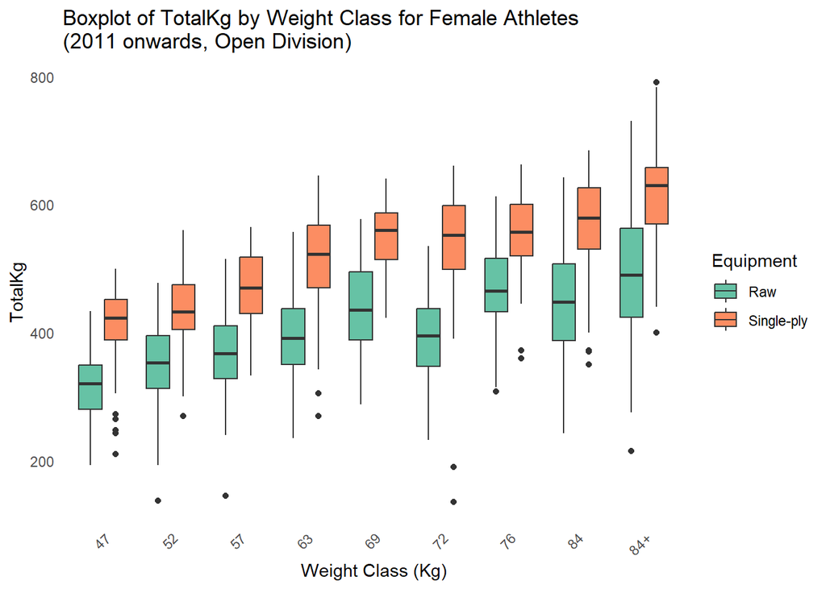

```r
# Female

ipf_female_data_2011_onwards_open <- ipf_female_data_clean %>%
  filter(Date >= as.Date("2011-01-01") & Division == "Open") %>%
  filter(!is.na(WeightClassKg))

female_boxplot_2011_onwards_open <- ggplot(ipf_female_data_2011_onwards_open, aes(x = as.factor(WeightClassKg), y = TotalKg, fill = Equipment)) +
  geom_boxplot() +
  theme_minimal() +
  labs(title = "Boxplot of TotalKg by Weight Class for Female Athletes \n(2011 onwards, Open Division)",
       x = "Weight Class (Kg)",
       y = "TotalKg") +
  scale_fill_brewer(palette = "Set2") +
  theme(axis.text.x = element_text(angle = 45, hjust = 1),
        panel.grid = element_blank()
  )

print(female_boxplot_2011_onwards_open)
```

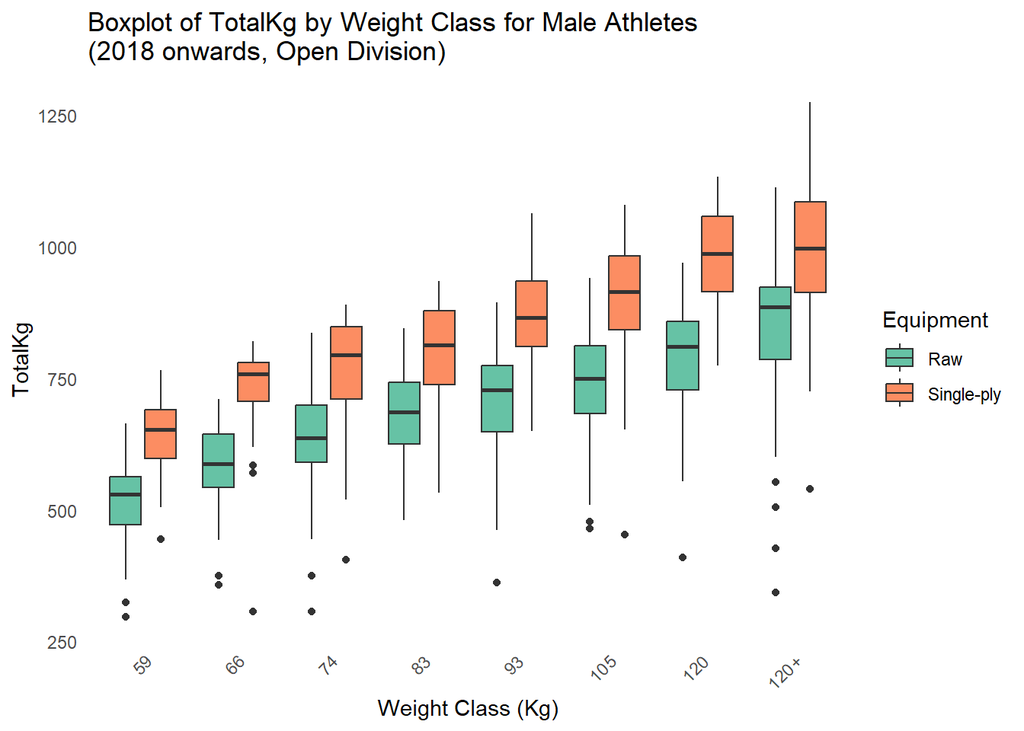

```r
# 2018

# Male

ipf_male_data_2018_onwards_open <- ipf_male_data_clean %>%
  filter(Date >= as.Date("2018-01-01") & Division == "Open") %>%
  filter(!is.na(WeightClassKg))

male_boxplot_2018_onwards_open <- ggplot(ipf_male_data_2018_onwards_open, aes(x = as.factor(WeightClassKg), y = TotalKg, fill = Equipment)) +
  geom_boxplot() +
  theme_minimal() +
labs(title = "Boxplot of TotalKg by Weight Class for Male Athletes \n(2018 onwards, Open Division)",
     x = "Weight Class (Kg)",
     y = "TotalKg") +
  scale_fill_brewer(palette = "Set2") +
  theme(
    axis.text.x = element_text(angle = 45, hjust = 1),
    panel.grid = element_blank()
  )

print(male_boxplot_2018_onwards_open)
```

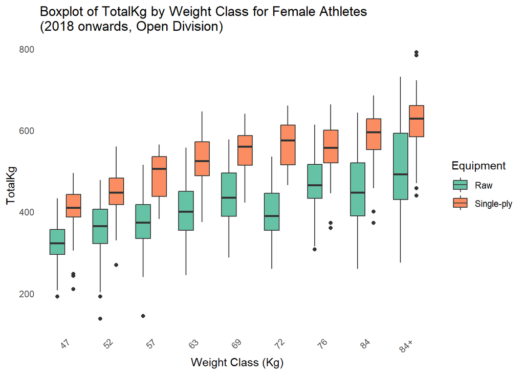

```r
# Female

ipf_female_data_2018_onwards_open <- ipf_female_data_clean %>%
  filter(Date >= as.Date("2018-01-01") & Division == "Open") %>%
  filter(!is.na(WeightClassKg))

female_boxplot_2018_onwards_open <- ggplot(ipf_female_data_2018_onwards_open, aes(x = as.factor(WeightClassKg), y = TotalKg, fill = Equipment)) +
  geom_boxplot() +
  theme_minimal() +
  labs(title = "Boxplot of TotalKg by Weight Class for Female Athletes \n(2018 onwards, Open Division)",
       x = "Weight Class (Kg)",
       y = "TotalKg") +
  scale_fill_brewer(palette = "Set2") +
  theme(
    axis.text.x = element_text(angle = 45, hjust = 1),
        panel.grid = element_blank()
  )

print(female_boxplot_2018_onwards_open)
```

### 5.8. Regression of totals by bodyweight, Open division, from 2011 onwards.

Most of the athletes’ **body weight** concentrates close to their **weight classes** limits. That is not the case for the higher **weight classes**. Since reach **body weights** beyond expected.

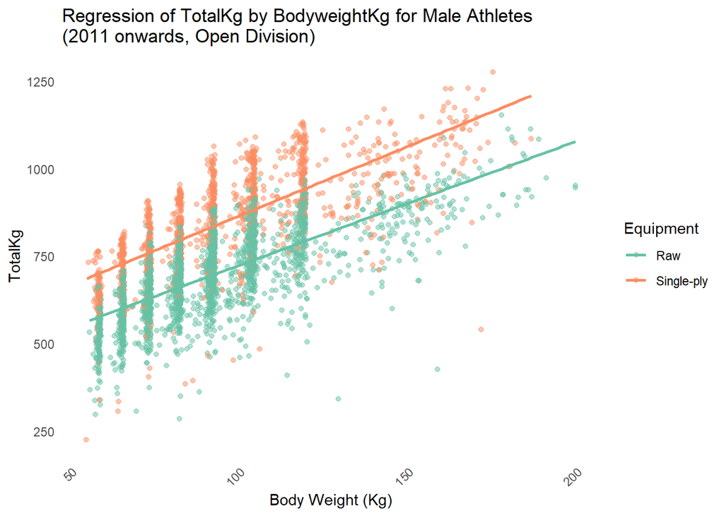

```r
# Male

ipf_male_data_2011_onwards_open <- ipf_male_data_clean %>%
  filter(Date >= as.Date("2011-01-01") & Division == "Open")

male_lm <- lm(TotalKg ~ BodyweightKg + Equipment, data = ipf_male_data_2011_onwards_open)

male_regression_plot_2011_onwards_open <- ggplot(ipf_male_data_2011_onwards_open, aes(x = BodyweightKg, y = TotalKg, color = Equipment)) +
  geom_point(alpha = 0.5, position = position_jitter(width = 0.2)) +
  geom_smooth(method = "lm", se = FALSE, aes(group = Equipment)) +
  theme_minimal() +
  labs(title = "Regression of TotalKg by BodyweightKg for Male Athletes \n(2011 onwards, Open Division)",
       x = "Body Weight (Kg)",
       y = "TotalKg") +
  scale_color_brewer(palette = "Set2") +
  theme(axis.text.x = element_text(angle = 45, hjust = 1),
        panel.grid = element_blank()
  )

print(male_regression_plot_2011_onwards_open)
```

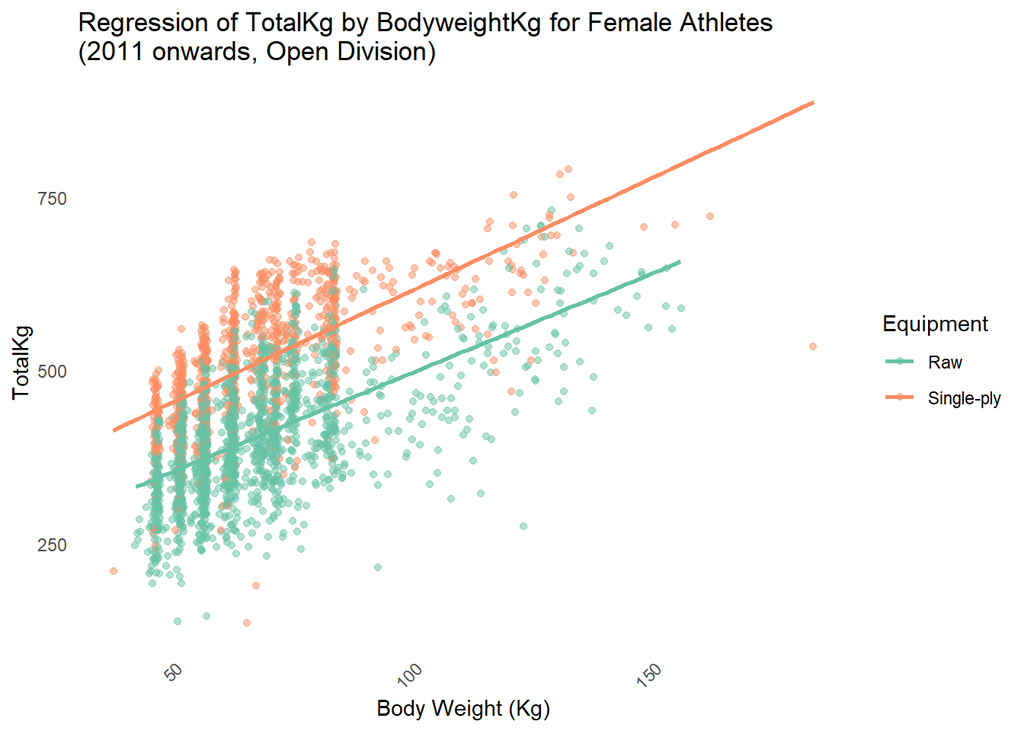

```r
# Female

ipf_female_data_2011_onwards_open <- ipf_female_data_clean %>%
  filter(Date >= as.Date("2011-01-01") & Division == "Open")

female_lm <- lm(TotalKg ~ BodyweightKg + Equipment, data = ipf_female_data_2011_onwards_open)

female_regression_plot_2011_onwards_open <- ggplot(ipf_female_data_2011_onwards_open, aes(x = BodyweightKg, y = TotalKg, color = Equipment)) +
  geom_point(alpha = 0.5, position = position_jitter(width = 0.2)) +
  geom_smooth(method = "lm", se = FALSE, aes(group = Equipment)) +
  theme_minimal() +
  labs(title = "Regression of TotalKg by BodyweightKg for Female Athletes \n(2011 onwards, Open Division)",
       x = "Body Weight (Kg)",
       y = "TotalKg") +
  scale_color_brewer(palette = "Set2") +
  theme(axis.text.x = element_text(angle = 45, hjust = 1),
        panel.grid = element_blank()
  )

print(female_regression_plot_2011_onwards_open)
```

### 5.9. ANOVA of totals by weight class, Open division.

An ANOVA is performed to verify inconsistencies of the **Totals** across **weight classes**.

```r
# Male

ipf_male_data_2011_onwards_open <- ipf_male_data_clean %>%
  filter(Date >= as.Date("2011-01-01") & Division == "Open")

anova_male_result <- aov(TotalKg ~ as.factor(WeightClassKg) * Equipment, data = ipf_male_data_2011_onwards_open)

# Female

ipf_female_data_2011_onwards_open <- ipf_female_data_clean %>%
  filter(Date >= as.Date("2011-01-01") & Division == "Open")

anova_female_result <- aov(TotalKg ~ as.factor(WeightClassKg) * Equipment, data = ipf_female_data_2011_onwards_open)
```

### 5.10. Tukey’s HSD.

Tukey´s Test suggests the female 69 and 72 **weight classes** present inconsistencies. A higher **weight class** should have higher means in the **TotalKg**, since they are correlated positively. The case must be studied separately.

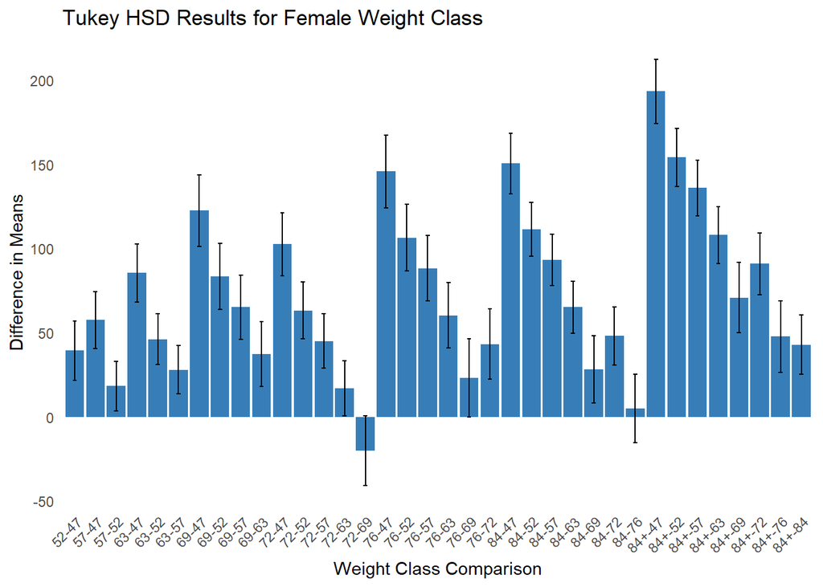

```r
# Male

tukey_male_result <- TukeyHSD(anova_male_result)

# Female

tukey_female_result <- TukeyHSD(anova_female_result)


# Results of Tukey's Test.

# Male

tukey_male_weightclass <- as.data.frame(tukey_male_result$`as.factor(WeightClassKg)`)
tukey_male_equipment <- as.data.frame(tukey_male_result$Equipment)
tukey_male_interaction <- as.data.frame(tukey_male_result$`as.factor(WeightClassKg):Equipment`)

tukey_male_weightclass$Comparison <- "WeightClass"
tukey_male_equipment$Comparison <- "Equipment"
tukey_male_interaction$Comparison <- "WeightClass:Equipment"

tukey_male_weightclass$Pair <- rownames(tukey_male_weightclass)
tukey_male_equipment$Pair <- rownames(tukey_male_equipment)
tukey_male_interaction$Pair <- rownames(tukey_male_interaction)

tukey_male_results <- rbind(tukey_male_weightclass, tukey_male_equipment, tukey_male_interaction)
rownames(tukey_male_results) <- NULL


# Female

tukey_female_weightclass <- as.data.frame(tukey_female_result$`as.factor(WeightClassKg)`)
tukey_female_equipment <- as.data.frame(tukey_female_result$Equipment)
tukey_female_interaction <- as.data.frame(tukey_female_result$`as.factor(WeightClassKg):Equipment`)

tukey_female_weightclass$Comparison <- "WeightClass"
tukey_female_equipment$Comparison <- "Equipment"
tukey_female_interaction$Comparison <- "WeightClass:Equipment"

tukey_female_weightclass$Pair <- rownames(tukey_female_weightclass)
tukey_female_equipment$Pair <- rownames(tukey_female_equipment)
tukey_female_interaction$Pair <- rownames(tukey_female_interaction)

tukey_female_results <- rbind(tukey_female_weightclass, tukey_female_equipment, tukey_female_interaction)
rownames(tukey_female_results) <- NULL


# Tukey's HSD graph: Comparison between weight classes.

ggplot(tukey_female_weightclass, aes(x = Pair, y = diff)) +
  geom_bar(stat = "identity", fill="#377EB8") +
  geom_errorbar(aes(ymin = lwr, ymax = upr), width = 0.2) +
  labs(
    title = "Tukey HSD Results for Female Weight Class",
    x = "Weight Class Comparison",
    y = "Difference in Means"
  ) +
  theme_minimal(base_family = "sans") +
  theme(
    axis.text.x = element_text(angle = 45, hjust = 1),
    panel.grid = element_blank(),
    legend.title = element_blank()
  )
```

### 5.11. Case study of female weight classes -69 & -72.

Up until 2024, the **69 female weight class** did not surpass the **72 weight class** in number of athletes.

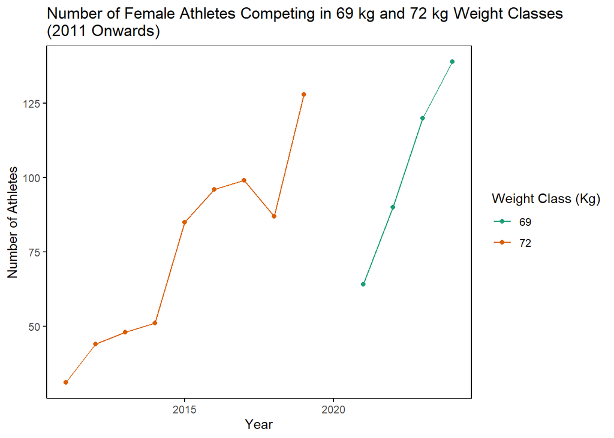

```r
# Number of female athletes on weight classes -69 & -72.

ipf_female_69_72 <- ipf_female_data_clean %>%
  filter(Date >= as.Date("2011-01-01") &
           WeightClassKg %in% c(69, 72))

athlete_counts <- ipf_female_69_72 %>%
  mutate(Year = as.numeric(format(Date, "%Y"))) %>%
  group_by(Year, WeightClassKg) %>%
  summarise(Count = n(), .groups = 'drop')


ggplot(athlete_counts, aes(x = Year, y = Count, color = as.factor(WeightClassKg))) +
  geom_line() +
  geom_point() +
  labs(title = "Number of Female Athletes Competing in 69 kg and 72 kg Weight Classes \n(2011 Onwards)",
       x = "Year",
       y = "Number of Athletes",
       color = "Weight Class (Kg)") +
  theme_minimal() +
  scale_color_brewer(palette = "Dark2") +
  theme(
    panel.grid = element_blank(),
    axis.line = element_line(color = "black"),
    panel.border = element_rect(color = "black", fill = NA),
    axis.ticks = element_line(color = "black")
  )
```

### 5.12. Average GL points per year in weight classes -69 & -72.

Even though **69** is an inferior **weight class** and was introduced later, from the first time it was incorporated, the average **Goodlift** points were higher than the **72 weight class**, which has inconsistent results along the years. These results confirm that, despite the amount of athletes, the **72 weight class** was considerably less competitive than its successor.

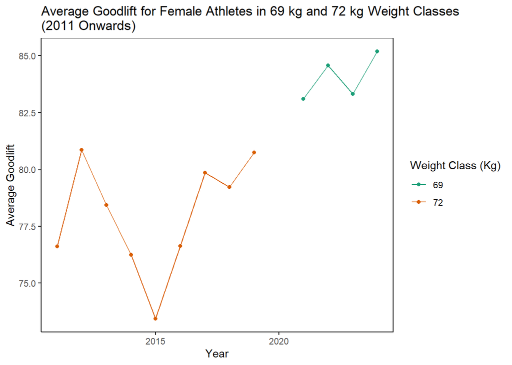

```r
average_goodlift <- ipf_female_69_72 %>%
  mutate(Year = as.numeric(format(Date, "%Y"))) %>%
  group_by(Year, WeightClassKg) %>%
  summarise(Average_Goodlift = mean(Goodlift, na.rm = TRUE), .groups = 'drop')


ggplot(average_goodlift, aes(x = Year, y = Average_Goodlift, color = as.factor(WeightClassKg))) +
  geom_line() +
  geom_point() +
  labs(title = "Average Goodlift for Female Athletes in 69 kg and 72 kg Weight Classes \n(2011 Onwards)",
       x = "Year",
       y = "Average Goodlift",
       color = "Weight Class (Kg)") +
  theme_minimal() +
  scale_color_brewer(palette = "Dark2") +
  theme(
    panel.grid = element_blank(),
    axis.line = element_line(color = "black"),
    panel.border = element_rect(color = "black", fill = NA),
    axis.ticks = element_line(color = "black")
  )
```

### 5.13. Density plot of totals by sex.

**TotalKg** in **Single-ply equipment** is a bit flatter than **Raw**.

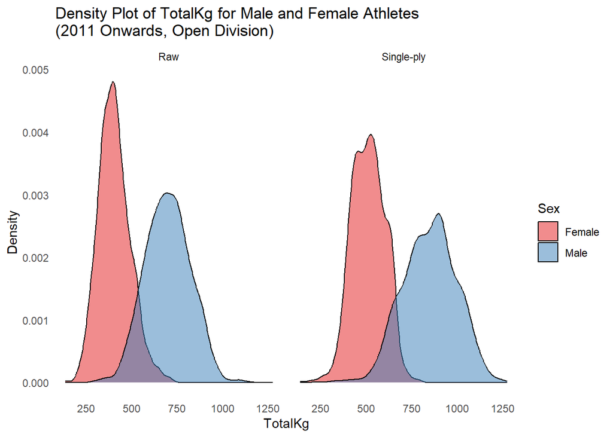

```r
ipf_male_data_2011_onwards_open <- ipf_male_data_clean %>%
  filter(Date >= as.Date("2011-01-01") & Division == "Open")

ipf_female_data_2011_onwards_open <- ipf_female_data_clean %>%
  filter(Date >= as.Date("2011-01-01") & Division == "Open")

combined_data_2011_onwards_open <- bind_rows(ipf_male_data_2011_onwards_open, ipf_female_data_2011_onwards_open)

ggplot(combined_data_2011_onwards_open, aes(x = TotalKg, fill = Sex)) +
  geom_density(alpha = 0.5) +
  facet_wrap(~ Equipment) +
  labs(title = "Density Plot of TotalKg for Male and Female Athletes \n(2011 Onwards, Open Division)",
       x = "TotalKg",
       y = "Density") +
  theme_minimal() +
  scale_fill_brewer(palette = "Set1",
                    labels = c("M" = "Male", "F" = "Female")) +
  theme(
    panel.grid = element_blank()
  )
```